# individual1

Molly Buckler

9/10/2020

```r
choco <- read.csv("https://raw.githubusercontent.com/xdaiISU/ds202materials/master/hwlabs/data/choco.csv")
str(choco)
```

```
## 'data.frame':    2312 obs. of  13 variables:
##  $ REF                 : int  2454 2458 2454 797 797 1015 1019 1011 1019 1011 ...
##  $ Company             : chr  "5150" "5150" "5150" "A. Morin" ...
##  $ Location            : chr  "U.S.A." "U.S.A." "U.S.A." "France" ...
##  $ Date                : int  2019 2019 2019 2012 2012 2013 2013 2013 2013 2013 ...
##  $ Bean_Origin         : chr  "Madagascar" "Dominican Republic" "Tanzania" "Peru" ...
##  $ Specific_Bean_Origin: chr  "Bejofo Estate, batch 1" "Zorzal, batch 1" "Kokoa Kamili, batch 1" "Peru" ...
##  $ Cocoa_Percent       : num  76 76 76 63 70 70 63 70 70 70 ...
##  $ Ingredients         : chr  "3- B,S,C" "3- B,S,C" "3- B,S,C" "4- B,S,C,L" ...
##  $ Characteristics1    : chr  "cocoa" "cocoa" "rich cocoa" "fruity" ...
##  $ Characteristics2    : chr  "blackberry" "vegetal" "fatty" "melon" ...
##  $ Characteristics3    : chr  "full body" "savory" "bready" "roasty" ...
##  $ Characteristics4    : chr  NA NA NA NA ...
##  $ Rating              : num  3.75 3.5 3.25 3.75 3.5 4 4 3.75 3.5 3.25 ...
```

#1)How are the ratings distributed? Create both a histogram and a boxplot and describe them. Don’t forget to mention outliers, if there are any.

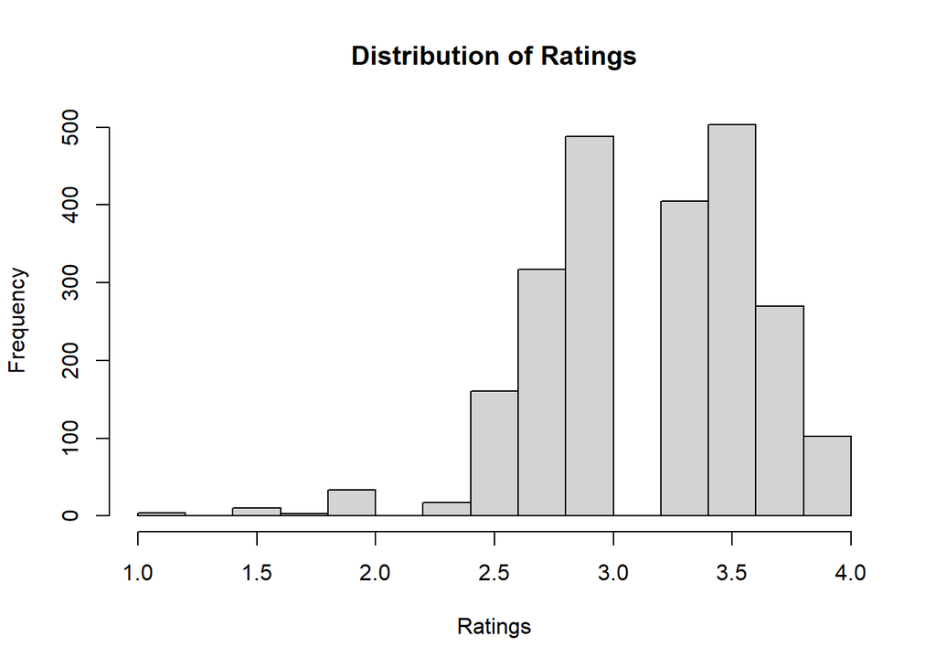

```r
hist(choco$Rating, main = 'Distribution of Ratings', xlab='Ratings')
```

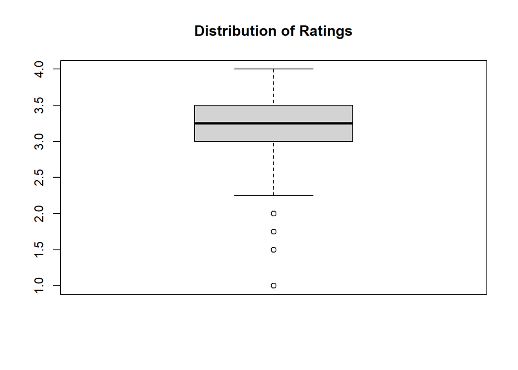

```r
boxplot(choco$Rating, main = 'Distribution of Ratings')
```

#The histogram is left skewed and the boxplot shows that there is four outliers and that the median is about 3.25.

#2)How does the number of ratings depend on the year? Draw a bar chart of the number of reports.

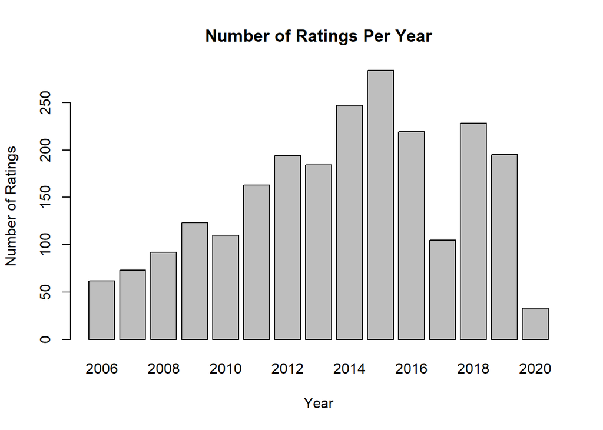

```r
countPerYear <- table(choco$Date)
barplot(countPerYear, main = 'Number of Ratings Per Year', xlab='Year', ylab='Number of Ratings')
```

#The barplot shows the number of ratings per year. The year with the most was 2015 and the year with the least amount of ratings was 2020.

#3)Do ratings depend on the cacao percentage of a chocolate bar? Create both numerical and graphical summaries, and explain.

```r
choco.numeric <- choco[,sapply(choco, is.numeric)]
head(choco.numeric)
```

```
##    REF Date Cocoa_Percent Rating
## 1 2454 2019            76   3.75
## 2 2458 2019            76   3.50
## 3 2454 2019            76   3.25
## 4  797 2012            63   3.75
## 5  797 2012            70   3.50
## 6 1015 2013            70   4.00
```

```r
cor(choco.numeric)
```

```
##                      REF       Date Cocoa_Percent      Rating
## REF           1.00000000 0.99163479    0.02104972  0.08364449
## Date          0.99163479 1.00000000    0.02186544  0.08596685
## Cocoa_Percent 0.02104972 0.02186544    1.00000000 -0.15101784
## Rating        0.08364449 0.08596685   -0.15101784  1.00000000
```

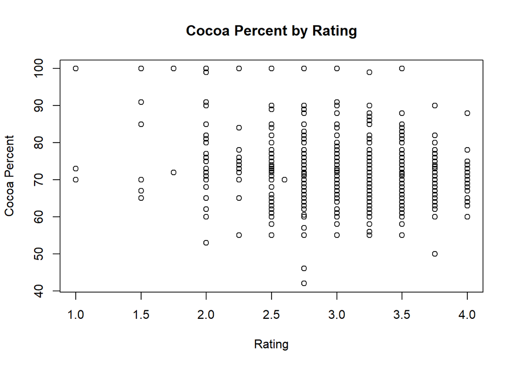

```r
plot(choco$Rating, choco$Cocoa_Percent, main='Cocoa Percent by Rating', xlab='Rating', ylab='Cocoa Percent')
```

#This scatter plot shows the relation between the Cocoa percent and the rating. The scatter plot shows that Cocoa percentage is concentrated around 70%. There is not much correlation between between the Cocoa percent and the rating. The correlation is -0.15101784.

#4)How do different characteristics of the chocolate compare? To elaborate, which characteristics tend to be more favorable and which ones are not? Create both numerical and graphical summaries, and explain.

[figure not shown]

```r
mRateWChar1 <- aggregate( Rating ~ Characteristics1, choco, mean )
barplot(mRateWChar1$Rating, main='Rating with Characteristics2')
```

```r
sRateChar1 <- mRateWChar1[order(-mRateWChar1$Rating), ]
head(sRateChar1)
```

```
##             Characteristics1 Rating
## 61                  cardamon      4
## 72  chocolate covered banana      4
## 111           distinct lemon      4
## 197               large nibs      4
## 206               ligt color      4
## 239                mild tart      4
```

[figure not shown]

```r
#Characteristics2
mRateWChar2 <- aggregate( Rating ~ Characteristics2, choco, mean )
barplot(mRateWChar2$Rating, main='Rating with Characteristics2')
```

```r
sRateChar2 <- mRateWChar2[order(-mRateWChar2$Rating), ]
head(sRateChar2)
```

```
##     Characteristics2 Rating
## 51     burnt brownie      4
## 90          cinnamon      4
## 116   delicate cocoa      4
## 117            dense      4
## 124    distinquished      4
## 189            homey      4
```

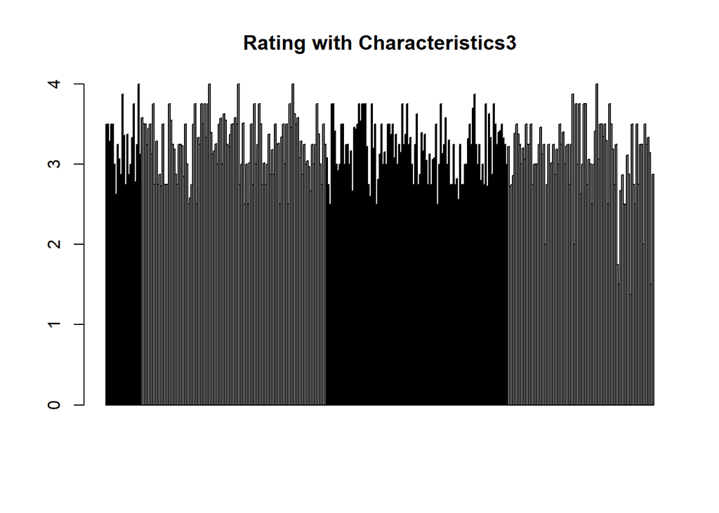

```r
#Characteristics3
mRateWChar3 <- aggregate( Rating ~ Characteristics3, choco, mean )
barplot(mRateWChar3$Rating, main='Rating with Characteristics3')
```

```r
sRateChar3 <- mRateWChar3[order(-mRateWChar3$Rating), ]
head(sRateChar3)
```

```
##     Characteristics3 Rating
## 21        blackberry  4.000
## 65             clove  4.000
## 83    delicate fruit  4.000
## 117     gentle roast  4.000
## 306        tangerine  4.000
## 11          balanced  3.875
```

#To show how the different characteristics of chocolate compare I aggregated the data with the different levels of characteristics and the mean of the rating for each individual characteristic. The characteristics that are most favorable in Characteristic1 was cardamo, chocolate covered banana, distinct lemon, lrge nibs, and light color. All these characteristics have a mean rating of 4. Barplots where also created to show the data.

#5)Brainstorm two analyses you would like to perform with your teammate. Describe in plain language what comparisons are you making. Create suitable numerical and graphical summaries for your analyses. Describe the results.

```r
#Regular Bean_Origin
mRateWBeanOrg <- aggregate( Rating ~ Bean_Origin, choco, mean )
sRateBeanOrg <- mRateWBeanOrg[order(-mRateWBeanOrg$Rating), ]
head(sRateBeanOrg)
```

```
##            Bean_Origin   Rating
## 56              Tobago 3.625000
## 44 Sao Tome & Principe 3.500000
## 46     Solomon Islands 3.450000
## 11               Congo 3.318182
## 55            Thailand 3.300000
## 13                Cuba 3.291667
```

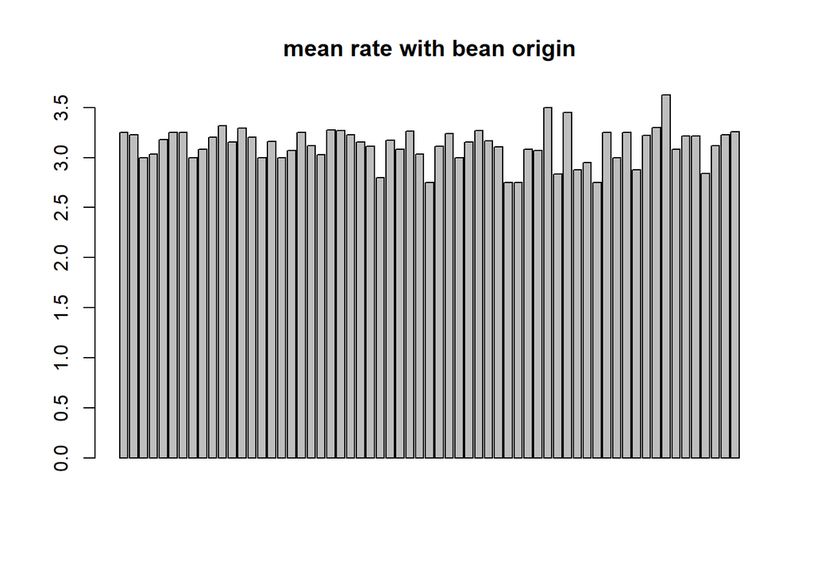

```r
barplot(mRateWBeanOrg$Rating, main='mean rate with bean origin')
```

```r
#Specific Bean_Origin
mRateWSBeanOrg <- aggregate( Rating ~ Specific_Bean_Origin, choco, mean )
sRateSBeanOrg <- mRateWSBeanOrg[order(-mRateWSBeanOrg$Rating), ]
head(sRateSBeanOrg)
```

```
##                                 Specific_Bean_Origin Rating
## 7                                        ABOCFA Coop      4
## 42                             Alto Beni, Cru Savage      4
## 95                                            Asante      4
## 108 Bachelor's Hall E., St. Thomas Parish, batch bh1      4
## 129         Bali, Sukrama Bros. Farm, Melaya, 62hr C      4
## 142                 Bejofo, Sambirano V., Akesson E.      4
```

[figure not shown]

```r
barplot(mRateWSBeanOrg$Rating, main='mean rate with specific bean origin')
```